# Pertemuan 1 - Pemulusan

Diva Nisfu Mustika

# Impor Data

Data yang digunakan adalah data IDX COMPOSITE (JKSE) dari April 2020 - Desember 2022 yang bersumber dari yahoo finance.

```r
#install.packages("rio") #install jika belum ada
library(tseries)
library(forecast)
library(TTR)
library(TSA)
library(imputeTS)
```

```r
library(ggplot2)
library(lmtest)
library(zoo)
library(rio)
data1 <- import("https://raw.githubusercontent.com/divanm/mpdw/main/Data/DATA%20IDX%20COMPOSITE%20JKSE.csv")
data1
```

```
##           Date     Open     High      Low    Close Adj Close     Volume
## 1   2020-04-06 4623.429 4975.536 4562.902 4649.079  4649.079  255758500
## 2   2020-04-13 4649.079 4747.725 4480.607 4634.821  4634.821  218419900
## 3   2020-04-20 4634.821 4669.542 4441.090 4496.064  4496.064  238397200
## 4   2020-04-27 4496.064 4726.774 4474.893 4716.403  4716.403  183906700
## 5   2020-05-04 4716.403 4716.403 4576.228 4597.430  4597.430  179791700
## 6   2020-05-11 4597.430 4659.862 4460.273 4507.607  4507.607  231060000
## 7   2020-05-18 4507.607 4609.042 4487.179 4545.952  4545.952  139287000
## 8   2020-05-25 4545.952 4755.957 4541.834 4753.612  4753.612  288083800
## 9   2020-06-01 4753.612 5014.764 4753.612 4947.782  4947.782  372565600
## 10  2020-06-08 4947.782 5139.406 4712.073 4880.359  4880.359  490084700
## 11  2020-06-15 4880.359 5018.985 4809.619 4942.275  4942.275  336775500
## 12  2020-06-22 4942.275 4977.651 4879.133 4904.088  4904.088  260206800
## 13  2020-06-29 4904.088 4997.482 4862.041 4973.794  4973.794  249816600
## 14  2020-07-06 4973.794 5111.564 4973.490 5031.256  5031.256  358094500
```

[output cut: 129 more lines]

Mengecek ringkasan dan tipe data

```r
str(data1)
```

```
## 'data.frame':    143 obs. of  7 variables:
##  $ Date     : IDate, format: "2020-04-06" "2020-04-13" ...
##  $ Open     : num  4623 4649 4635 4496 4716 ...
##  $ High     : num  4976 4748 4670 4727 4716 ...
##  $ Low      : num  4563 4481 4441 4475 4576 ...
##  $ Close    : num  4649 4635 4496 4716 4597 ...
##  $ Adj Close: num  4649 4635 4496 4716 4597 ...
##  $ Volume   : int  255758500 218419900 238397200 183906700 179791700 231060000 139287000 288083800 372565600 490084700 ...
```

```r
summary(data1)
```

```
##       Date                 Open           High           Low
##  Min.   :2020-04-06   Min.   :4496   Min.   :4609   Min.   :4441
##  1st Qu.:2020-12-10   1st Qu.:5808   1st Qu.:5918   1st Qu.:5737
##  Median :2021-08-16   Median :6256   Median :6319   Median :6162
##  Mean   :2021-08-16   Mean   :6185   Mean   :6276   Mean   :6090
##  3rd Qu.:2022-04-21   3rd Qu.:6869   3rd Qu.:6956   3rd Qu.:6749
##  Max.   :2022-12-26   Max.   :7246   Max.   :7377   Max.   :7175
##                       NA's   :1      NA's   :1      NA's   :1
##      Close        Adj Close        Volume
##  Min.   :4496   Min.   :4496   Min.   :1.175e+08
##  1st Qu.:5820   1st Qu.:5820   1st Qu.:6.086e+08
##  Median :6237   Median :6237   Median :8.210e+08
##  Mean   :6196   Mean   :6196   Mean   :7.996e+08
##  3rd Qu.:6874   3rd Qu.:6874   3rd Qu.:1.006e+09
##  Max.   :7243   Max.   :7243   Max.   :1.535e+09
##  NA's   :1      NA's   :1      NA's   :1
```

Mengubah tipe data Close menjadi numeric dan tipe data Date menjadi Date

```r
data1$Date <- as.Date(data1$Date)
data1$Close <- as.numeric(data1$Close)
```

Mengecek keberadaan missing value

```r
# Cek apakah ada missing value:
data1[which(is.na(data1$Close)),]
```

```
##           Date Open High Low Close Adj Close Volume
## 109 2022-05-02   NA   NA  NA    NA        NA     NA
```

```r
data <- na_interpolation(data1, option = "spline")
data[109,]
```

```
##           Date    Open     High      Low    Close Adj Close    Volume
## 109 2022-05-02 7324.78 7258.343 6799.028 6840.217  6840.217 697324161
```

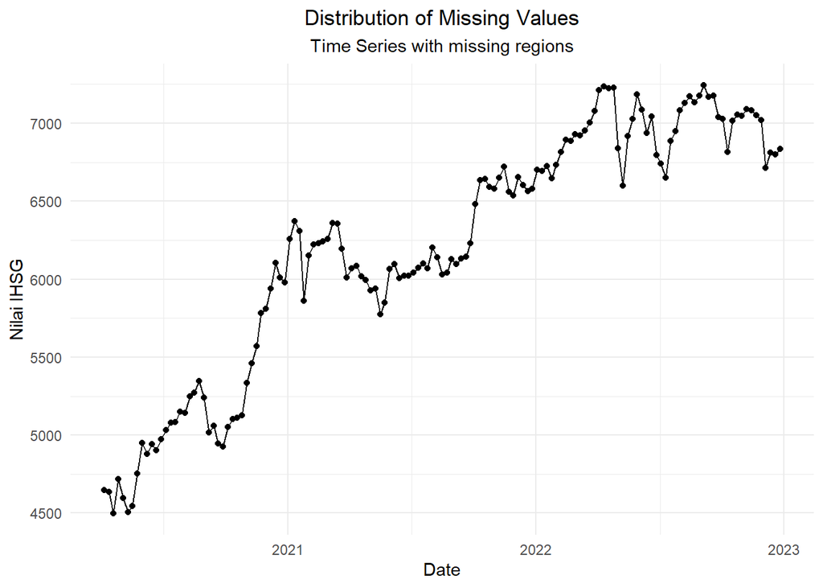

```r
# Cek berdasarkan plot
ggplot(data, aes(x=Date, y=Close), x_axis_labels=daily$Date)+
  labs(title = "Distribution of Missing Values",
       y="Nilai IHSG",
       subtitle = "Time Series with missing regions") +
  geom_line() + geom_point() + theme_minimal() +
  theme(legend.position="none", plot.title = element_text(hjust = 0.5),
        plot.subtitle = element_text(hjust = 0.5))
```

```r
# Cek berdasarkan tabel
data[which(is.na(data$Close)),]
```

```
## [1] Date      Open      High      Low       Close     Adj Close Volume
## <0 rows> (or 0-length row.names)
```

Setelah dilakukan penanganan, dapat terlihat bahwa nilai data Close pada tanggal 2 mei 2022 telah terisi dengan nilai 6840.217

# Eksplorasi Data

Eksplorasi data diperlukan untuk melihat pola dari data time series. Selain itu, eksplorasi juga berguna dalam pembagian data training dan data testing. Data testing yang baik adalah data testing yang memiliki pola seperti data trainingnya. Maka dari itu, diperlukan eksplorasi data untuk menentukan proporsi terbaik data training vs data testing.

Mengubah data agar terbaca sebagai data deret waktu dengan fungsi `ts()` .

```r
Close <- data$Close
data1.ts <- ts(Close)
data1.ts
```

```
## Time Series:
## Start = 1
## End = 143
## Frequency = 1
##   [1] 4649.079 4634.821 4496.064 4716.403 4597.430 4507.607 4545.952 4753.612
##   [9] 4947.782 4880.359 4942.275 4904.088 4973.794 5031.256 5079.585 5082.991
##  [17] 5149.627 5143.893 5247.690 5272.810 5346.659 5239.851 5016.712 5059.223
##  [25] 4945.791 4926.734 5053.663 5103.414 5112.188 5128.225 5335.529 5461.058
##  [33] 5571.656 5783.335 5810.483 5938.329 6104.324 6008.709 5979.073 6257.835
##  [41] 6373.412 6307.127 5862.352 6151.729 6222.521 6231.932 6241.796 6258.749
##  [49] 6358.209 6356.160 6195.562 6011.456 6070.209 6086.258 6016.864 5995.616
##  [57] 5928.309 5938.351 5773.120 5848.616 6065.166 6095.497 6007.120 6022.399
##  [65] 6023.008 6039.844 6072.510 6101.690 6070.039 6203.431 6139.492 6030.772
##  [73] 6041.366 6126.921 6094.873 6133.246 6144.815 6228.845 6481.769 6633.338
##  [81] 6643.738 6591.346 6581.785 6651.054 6720.263 6561.553 6538.506 6652.922
##  [89] 6601.932 6562.900 6581.482 6701.316 6693.401 6726.373 6645.511 6731.391
##  [97] 6815.607 6892.818 6888.171 6928.328 6922.602 6954.965 7002.532 7078.760
## [105] 7210.835 7235.532 7225.606 7228.914 6840.217 6597.993 6918.144 7026.256
## [113] 7182.961 7086.648 6936.967 7042.937 6794.328 6740.219 6651.905 6886.962
## [121] 6951.123 7084.655 7129.277 7172.434 7135.248 7177.179 7242.656 7168.870
## [129] 7178.583 7040.798 7026.783 6814.530 7017.771 7056.040 7045.527 7089.206
## [137] 7082.181 7053.150 7019.639 6715.118 6812.193 6800.673 6835.808
```

Mengambil kolom data yang diambil yaitu Date dan Close

```r
data <- data[c("Date","Close")]
View(data)
```

Membuat plot data deret waktu

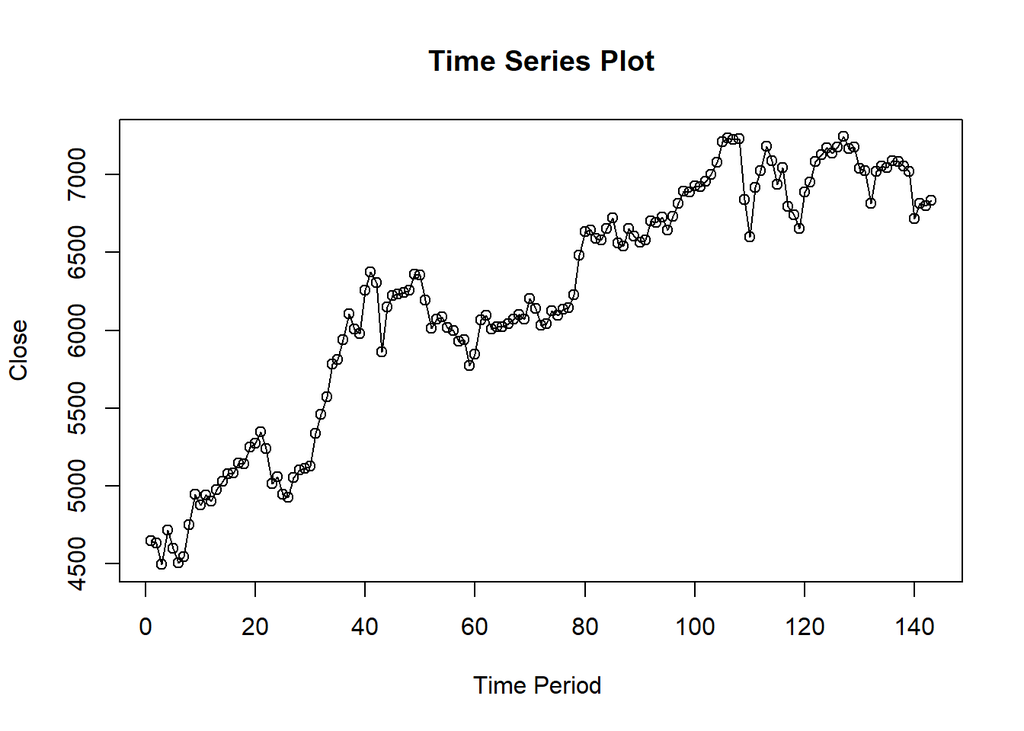

```r
ts.plot(data1.ts, xlab="Time Period ", ylab="Close",
        main = "Time Series Plot")
points(data1.ts)
```

# Double Moving Average (DMA) dan Double Exponential Smoothing (DES)

## Pembagian Data

Pembagian data latih dan data uji dilakukan dengan perbandingan 80% data latih dan 20% data uji.

```r
#membagi data latih dan data uji
training_ma <- data[1:115,]
testing_ma <- data[116:143,]
train_ma.ts <- ts(training_ma$Close)
test_ma.ts <- ts(testing_ma$Close)
```

## Eksplorasi Data

Eksplorasi data dilakukan pada keseluruhan data, data latih serta data uji menggunakan plot data deret waktu.

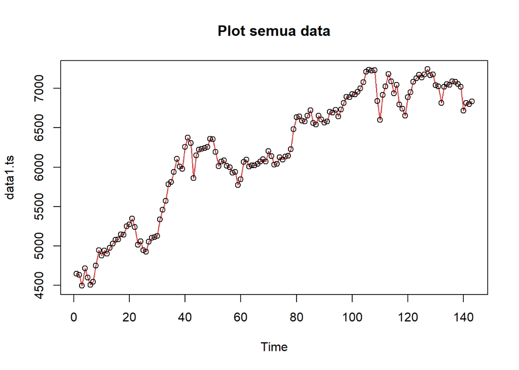

```r
#eksplorasi keseluruhan data
plot(data1.ts, col="red",main="Plot semua data")
points(data1.ts)
```

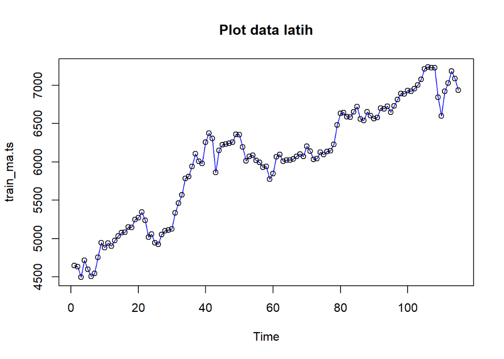

```r
#eksplorasi data latih
plot(train_ma.ts, col="blue",main="Plot data latih")
points(train_ma.ts)
```

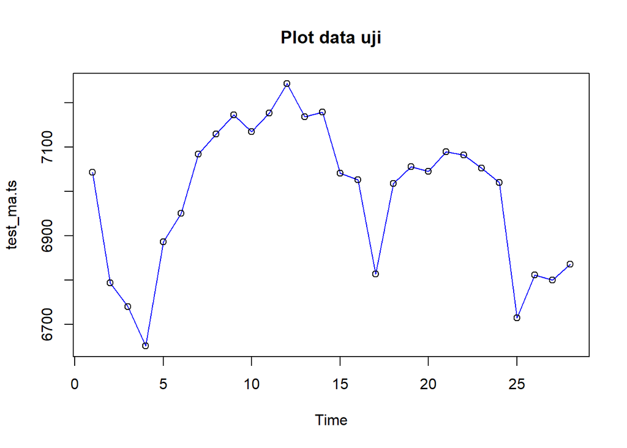

```r
#eksplorasi data uji
plot(test_ma.ts, col="blue",main="Plot data uji")
points(test_ma.ts)
```

Eksplorasi data juga dapat dilakukan menggunakan package `ggplot2` dengan terlebih dahulu memanggil library *package* `ggplot2`.

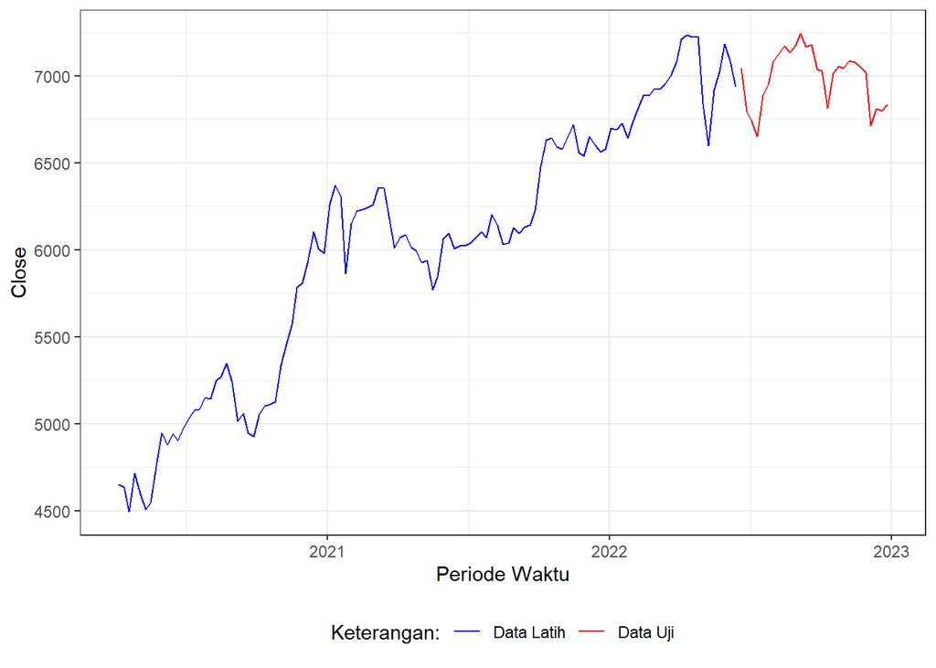

```r
#Eksplorasi dengan GGPLOT
library(ggplot2)
ggplot() +
  geom_line(data = training_ma, aes(x = Date, y = Close, col = "Data Latih")) +
  geom_line(data = testing_ma, aes(x = Date, y = Close, col = "Data Uji")) +
  labs(x = "Periode Waktu", y = "Close", color = "Legend") +
  scale_colour_manual(name="Keterangan:", breaks = c("Data Latih", "Data Uji"),
                      values = c("blue", "red")) +
  theme_bw() + theme(legend.position = "bottom",
                     plot.caption = element_text(hjust=0.5, size=12))
```

## Double Moving Average (DMA)

Pemulusan menggunakan metode SMA dilakukan dengan fungsi `SMA()`. Dalam hal ini akan dilakukan pemulusan dengan parameter `m=4`.

```r
data.sma<-SMA(train_ma.ts, n=4)
data.sma
```

```
## Time Series:
## Start = 1
## End = 115
## Frequency = 1
##   [1]       NA       NA       NA 4624.092 4611.179 4579.376 4591.848 4601.150
##   [9] 4688.738 4781.926 4881.007 4918.626 4925.129 4962.853 4997.181 5041.906
##  [17] 5085.865 5114.024 5156.050 5203.505 5252.763 5276.753 5219.008 5165.611
##  [25] 5065.394 4987.115 4996.353 5007.401 5049.000 5099.373 5169.839 5259.250
##  [33] 5374.117 5537.894 5656.633 5775.951 5909.118 5965.461 6007.609 6087.485
##  [41] 6154.757 6229.362 6200.182 6173.655 6135.932 6117.134 6211.995 6238.750
##  [49] 6272.672 6303.729 6292.170 6230.347 6158.347 6090.871 6046.197 6042.237
##  [57] 6006.762 5969.785 5908.849 5872.099 5906.313 5945.600 6004.100 6047.546
##  [65] 6037.006 6023.093 6039.440 6059.263 6071.021 6111.917 6128.663 6110.934
##  [73] 6103.765 6084.638 6073.483 6099.102 6124.964 6150.445 6247.169 6372.192
##  [81] 6496.922 6587.548 6612.552 6616.981 6636.112 6628.664 6617.844 6618.311
##  [89] 6588.728 6589.065 6599.809 6611.907 6634.775 6675.643 6691.650 6699.169
##  [97] 6729.721 6771.332 6831.997 6881.231 6907.980 6923.516 6952.107 6989.715
## [105] 7061.773 7131.915 7187.683 7225.222 7132.567 6973.182 6896.317 6845.652
## [113] 6931.339 7053.502 7058.208
```

Data pemulusan pada periode ke-t selanjutnya digunakan sebagai nilai peramalan pada periode ke t+1 sehingga hasil peramalan 1 periode kedepan adalah sebagai berikut.

```r
data.ramal<-c(NA,data.sma)
data.ramal #forecast 1 periode ke depan
```

```
##   [1]       NA       NA       NA       NA 4624.092 4611.179 4579.376 4591.848
##   [9] 4601.150 4688.738 4781.926 4881.007 4918.626 4925.129 4962.853 4997.181
##  [17] 5041.906 5085.865 5114.024 5156.050 5203.505 5252.763 5276.753 5219.008
##  [25] 5165.611 5065.394 4987.115 4996.353 5007.401 5049.000 5099.373 5169.839
##  [33] 5259.250 5374.117 5537.894 5656.633 5775.951 5909.118 5965.461 6007.609
##  [41] 6087.485 6154.757 6229.362 6200.182 6173.655 6135.932 6117.134 6211.995
##  [49] 6238.750 6272.672 6303.729 6292.170 6230.347 6158.347 6090.871 6046.197
##  [57] 6042.237 6006.762 5969.785 5908.849 5872.099 5906.313 5945.600 6004.100
##  [65] 6047.546 6037.006 6023.093 6039.440 6059.263 6071.021 6111.917 6128.663
##  [73] 6110.934 6103.765 6084.638 6073.483 6099.102 6124.964 6150.445 6247.169
##  [81] 6372.192 6496.922 6587.548 6612.552 6616.981 6636.112 6628.664 6617.844
##  [89] 6618.311 6588.728 6589.065 6599.809 6611.907 6634.775 6675.643 6691.650
##  [97] 6699.169 6729.721 6771.332 6831.997 6881.231 6907.980 6923.516 6952.107
## [105] 6989.715 7061.773 7131.915 7187.683 7225.222 7132.567 6973.182 6896.317
## [113] 6845.652 6931.339 7053.502 7058.208
```

Selanjutnya akan dilakukan peramalan sejumlah data uji yaitu 28 periode. Pada metode SMA, hasil peramalan 28 periode ke depan akan bernilai sama dengan hasil peramalan 1 periode kedepan. Dalam hal ini akan dilakukan pengguabungan data aktual train, data hasil pemulusan dan data hasil ramalan 28 periode kedepan.

```r
data.gab<-cbind(aktual=c(train_ma.ts,rep(NA,28)),pemulusan=c(data.sma,rep(NA,28)),ramalan=c(data.ramal,rep(data.ramal[length(data.ramal)],27)))
data.gab #forecast 28 periode ke depan
```

```
##          aktual pemulusan  ramalan
##   [1,] 4649.079        NA       NA
##   [2,] 4634.821        NA       NA
##   [3,] 4496.064        NA       NA
##   [4,] 4716.403  4624.092       NA
##   [5,] 4597.430  4611.179 4624.092
##   [6,] 4507.607  4579.376 4611.179
##   [7,] 4545.952  4591.848 4579.376
##   [8,] 4753.612  4601.150 4591.848
##   [9,] 4947.782  4688.738 4601.150
##  [10,] 4880.359  4781.926 4688.738
##  [11,] 4942.275  4881.007 4781.926
##  [12,] 4904.088  4918.626 4881.007
##  [13,] 4973.794  4925.129 4918.626
##  [14,] 5031.256  4962.853 4925.129
```

[output cut: 129 more lines]

```r
dma <- SMA(data.sma, n = 4)
At <- 2*data.sma - dma
Bt <- 2/(4-1)*(data.sma - dma)
data.dma<- At+Bt
data.ramal2<- c(NA, data.dma)

t = 1:28
f = c()

for (i in t) {
  f[i] = At[length(At)] + Bt[length(Bt)]*(i)
}

data.gab2 <- cbind(aktual = c(train_ma.ts,rep(NA,28)), pemulusan1 = c(data.sma,rep(NA,28)),pemulusan2 = c(data.dma, rep(NA,28)),At = c(At, rep(NA,28)), Bt = c(Bt,rep(NA,28)),ramalan = c(data.ramal2, f[-1]))
data.gab2
```

```
##          aktual pemulusan1 pemulusan2       At          Bt  ramalan
##   [1,] 4649.079         NA         NA       NA          NA       NA
##   [2,] 4634.821         NA         NA       NA          NA       NA
##   [3,] 4496.064         NA         NA       NA          NA       NA
##   [4,] 4716.403   4624.092         NA       NA          NA       NA
##   [5,] 4597.430   4611.179         NA       NA          NA       NA
##   [6,] 4507.607   4579.376         NA       NA          NA       NA
##   [7,] 4545.952   4591.848   4575.555 4582.072   -6.517171       NA
##   [8,] 4753.612   4601.150   4609.920 4606.412    3.507894 4575.555
##   [9,] 4947.782   4688.738   4811.172 4762.198   48.973429 4609.920
##  [10,] 4880.359   4781.926   4975.277 4897.937   77.340373 4811.172
##  [11,] 4942.275   4881.007   5119.009 5023.808   95.201009 4975.277
##  [12,] 4904.088   4918.626   5087.045 5019.678   67.367737 5119.009
##  [13,] 4973.794   4925.129   5005.890 4973.586   32.304586 5087.045
##  [14,] 5031.256   4962.853   5031.102 5003.803   27.299601 5005.890
```

[output cut: 129 more lines]

Hasil pemulusan menggunakan metode DMA divisualisasikan sebagai berikut

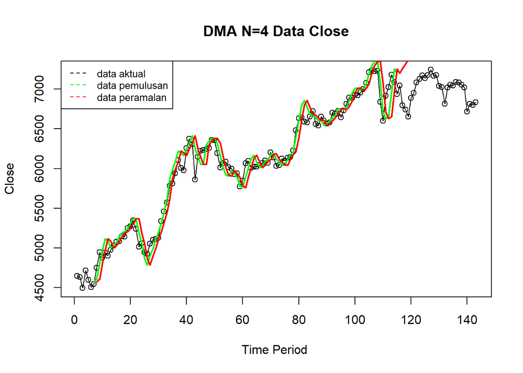

```r
ts.plot(data1.ts, xlab="Time Period ", ylab="Close", main= "DMA N=4 Data Close")
points(data1.ts)
lines(data.gab2[,3],col="green",lwd=2)
lines(data.gab2[,6],col="red",lwd=2)
legend("topleft",c("data aktual","data pemulusan","data peramalan"), lty=8, col=c("black","green","red"), cex=0.8)
```

Selanjutnya perhitungan akurasi dilakukan baik pada data latih maupun data uji. Perhitungan akurasi dilakukan dengan ukuran akurasi SSE, MSE dan MAPE.

```r
#Menghitung nilai keakuratan data latih
error_train.dma = train_ma.ts-data.ramal2[1:length(train_ma.ts)]
SSE_train.dma = sum(error_train.dma[8:length(train_ma.ts)]^2)
MSE_train.dma = mean(error_train.dma[8:length(train_ma.ts)]^2)
MAPE_train.dma = mean(abs((error_train.dma[8:length(train_ma.ts)]/train_ma.ts[8:length(train_ma.ts)])*100))

akurasi_train.dma <- matrix(c(SSE_train.dma, MSE_train.dma, MAPE_train.dma))
row.names(akurasi_train.dma)<- c("SSE", "MSE", "MAPE")
colnames(akurasi_train.dma) <- c("Akurasi m = 4")
akurasi_train.dma
```

```
##      Akurasi m = 4
## SSE   2.996853e+06
## MSE   2.774864e+04
## MAPE  1.979160e+00
```

Perhitungan akurasi pada data latih menggunakan nilai MAPE menghasilkan nilai MAPE yang kurang dari 10% sehingga dikategorikan sangat baik. Selanjutnya, perhitungan nilai akurasi dilakukan pada data uji.

```r
#Menghitung nilai keakuratan data uji
error_test.dma = test_ma.ts-data.gab2[116:143,6]
SSE_test.dma = sum(error_test.dma^2)
MSE_test.dma = mean(error_test.dma^2)
MAPE_test.dma = mean(abs((error_test.dma/test_ma.ts*100)))

akurasi_test.dma <- matrix(c(SSE_test.dma, MSE_test.dma, MAPE_test.dma))
row.names(akurasi_test.dma)<- c("SSE", "MSE", "MAPE")
colnames(akurasi_test.dma) <- c("Akurasi m = 4")
akurasi_test.dma
```

```
##      Akurasi m = 4
## SSE   3.411581e+07
## MSE   1.218422e+06
## MAPE  1.414680e+01
```

## Double Exponential Smoothing (DES)

Nilai pemulusan pada periode ke-t didapat dari persamaan:

$$\tilde{y}_T=\lambda y_t+(1-\lambda)\tilde{y}_{T-1}$$

Nilai parameter $\lambda$ adalah nilai antara 0 dan 1.

Nilai pemulusan periode ke-t bertindak sebagai nilai ramalan pada periode ke-$(T+\tau)$.

$$\tilde{y}_{T+\tau}(T)=\tilde{y}_T$$

Metode pemulusan *Double Exponential Smoothing* (DES) digunakan untuk data yang memiliki pola tren. Metode DES adalah metode semacam SES, hanya saja dilakukan dua kali, yaitu pertama untuk tahapan ‘level’ dan kedua untuk tahapan ‘tren’. Pemulusan menggunakan metode ini akan menghasilkan peramalan tidak konstan untuk periode berikutnya.

Pemulusan dengan metode DES kali ini akan menggunakan fungsi `HoltWinters()` . Jika sebelumnya nilai argumen `beta` dibuat `FALSE` , kali ini argumen tersebut akan diinisialisasi bersamaan dengan nilai `alpha` .

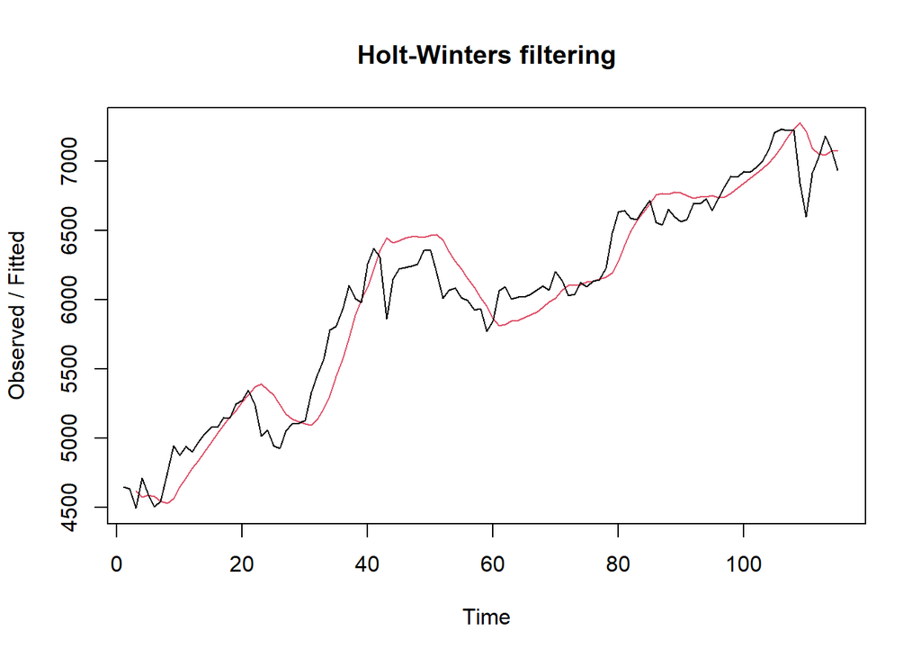

```r
#Lamda=0.2 dan gamma=0.2
des.1<- HoltWinters(train_ma.ts, gamma = FALSE, beta = 0.2, alpha = 0.2)
plot(des.1)
```

```r
#ramalan
ramalandes1<- forecast(des.1, h=28)
ramalandes1
```

```
##     Point Forecast    Lo 80    Hi 80    Lo 95    Hi 95
## 116       7043.486 6783.969 7303.002 6646.590 7440.382
## 117       7038.680 6771.794 7305.565 6630.513 7446.846
## 118       7033.874 6757.273 7310.475 6610.849 7456.899
## 119       7029.068 6740.269 7317.867 6587.389 7470.747
## 120       7024.262 6720.728 7327.796 6560.047 7488.478
## 121       7019.456 6698.662 7340.250 6528.844 7510.068
## 122       7014.650 6674.140 7355.161 6493.884 7535.416
## 123       7009.844 6647.264 7372.425 6455.325 7564.364
## 124       7005.039 6618.159 7391.918 6413.357 7596.720
## 125       7000.233 6586.958 7413.508 6368.183 7632.282
## 126       6995.427 6553.791 7437.062 6320.004 7670.850
## 127       6990.621 6518.786 7462.455 6269.012 7712.230
## 128       6985.815 6482.059 7489.571 6215.387 7756.243
## 129       6981.009 6443.716 7518.302 6159.291 7802.727
## 130       6976.203 6403.854 7548.553 6100.870 7851.536
## 131       6971.397 6362.556 7580.238 6040.255 7902.539
## 132       6966.591 6319.901 7613.282 5977.564 7955.619
## 133       6961.786 6275.955 7647.616 5912.898 8010.673
## 134       6956.980 6230.779 7683.180 5846.352 8067.608
## 135       6952.174 6184.426 7719.921 5778.006 8126.342
## 136       6947.368 6136.945 7757.790 5707.934 8186.802
## 137       6942.562 6088.379 7796.745 5636.201 8248.923
## 138       6937.756 6038.765 7836.747 5562.868 8312.644
## 139       6932.950 5988.140 7877.761 5487.987 8377.913
## 140       6928.144 5936.534 7919.755 5411.607 8444.682
## 141       6923.338 5883.976 7962.700 5333.772 8512.905
## 142       6918.533 5830.494 8006.571 5254.521 8582.544
## 143       6913.727 5776.110 8051.344 5173.891 8653.562
```

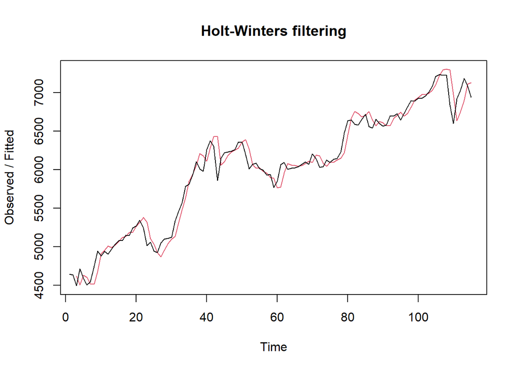

```r
#Lamda=0.6 dan gamma=0.3
des.2<- HoltWinters(train_ma.ts, gamma = FALSE, beta = 0.3, alpha = 0.6)
plot(des.2)
```

```r
#ramalan
ramalandes2<- forecast(des.2, h=28)
ramalandes2
```

```
##     Point Forecast    Lo 80     Hi 80    Lo 95     Hi 95
## 116       7014.581 6835.589  7193.572 6740.837  7288.325
## 117       7014.706 6787.705  7241.708 6667.537  7361.876
## 118       7014.832 6730.129  7299.536 6579.416  7450.249
## 119       7014.958 6664.683  7365.233 6479.259  7550.658
## 120       7015.084 6592.573  7437.595 6368.909  7661.259
## 121       7015.210 6514.609  7515.810 6249.607  7780.812
## 122       7015.336 6431.362  7599.309 6122.225  7908.446
## 123       7015.461 6343.253  7687.669 5987.408  8043.515
## 124       7015.587 6250.608  7780.566 5845.653  8185.522
## 125       7015.713 6153.687  7877.739 5697.358  8334.068
## 126       7015.839 6052.705  7978.973 5542.852  8488.825
## 127       7015.965 5947.843  8084.087 5382.413  8649.517
## 128       7016.091 5839.257  8192.924 5216.279  8815.902
## 129       7016.216 5727.085  8305.348 5044.659  8987.773
## 130       7016.342 5611.447  8421.238 4867.740  9164.944
## 131       7016.468 5492.452  8540.484 4685.687  9347.249
## 132       7016.594 5370.199  8662.989 4498.649  9534.538
## 133       7016.720 5244.776  8788.664 4306.765  9726.674
## 134       7016.845 5116.265  8917.425 4110.159  9923.532
## 135       7016.971 4984.743  9049.199 3908.947 10124.996
## 136       7017.097 4850.279  9183.915 3703.235 10330.959
## 137       7017.223 4712.938  9321.508 3493.123 10541.323
## 138       7017.349 4572.780  9461.917 3278.704 10755.993
## 139       7017.475 4429.863  9605.086 3060.065 10974.884
## 140       7017.600 4284.241  9750.960 2837.288 11197.913
## 141       7017.726 4135.962  9899.490 2610.449 11425.004
## 142       7017.852 3985.076 10050.628 2379.621 11656.083
## 143       7017.978 3831.627 10204.329 2144.874 11891.081
```

Selanjutnya jika ingin membandingkan plot data latih dan data uji adalah sebagai berikut.

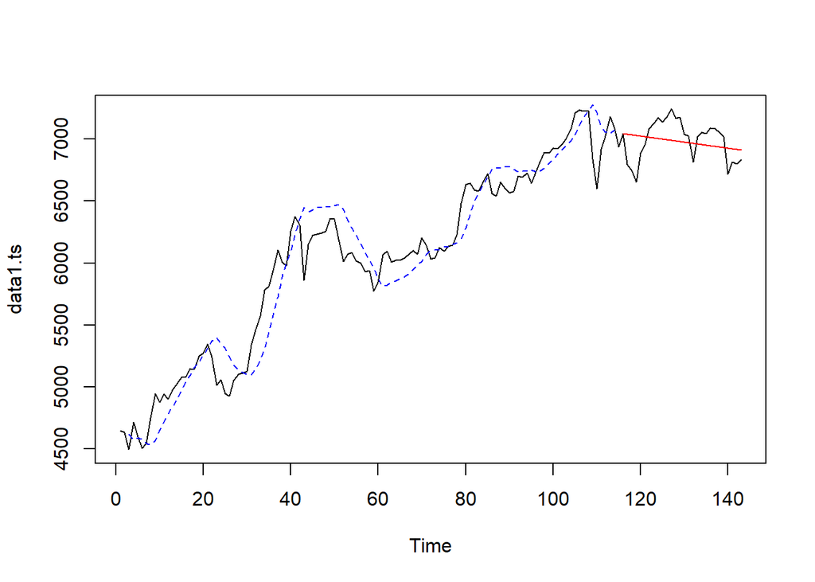

```r
#Visually evaluate the prediction
plot(data1.ts)
lines(des.1$fitted[,1], lty=2, col="blue")
lines(ramalandes1$mean, col="red")
```

Untuk mendapatkan nilai parameter optimum dari DES, argumen `alpha` dan `beta` dapat dibuat `NULL` seperti berikut.

```r
#Lamda dan gamma optimum
des.opt<- HoltWinters(train_ma.ts, gamma = FALSE)
des.opt
```

```
## Holt-Winters exponential smoothing with trend and without seasonal component.
##
## Call:
## HoltWinters(x = train_ma.ts, gamma = FALSE)
##
## Smoothing parameters:
##  alpha: 1
##  beta : 0.0197573
##  gamma: FALSE
##
## Coefficients:
##         [,1]
## a 6936.96680
## b   12.49961
```

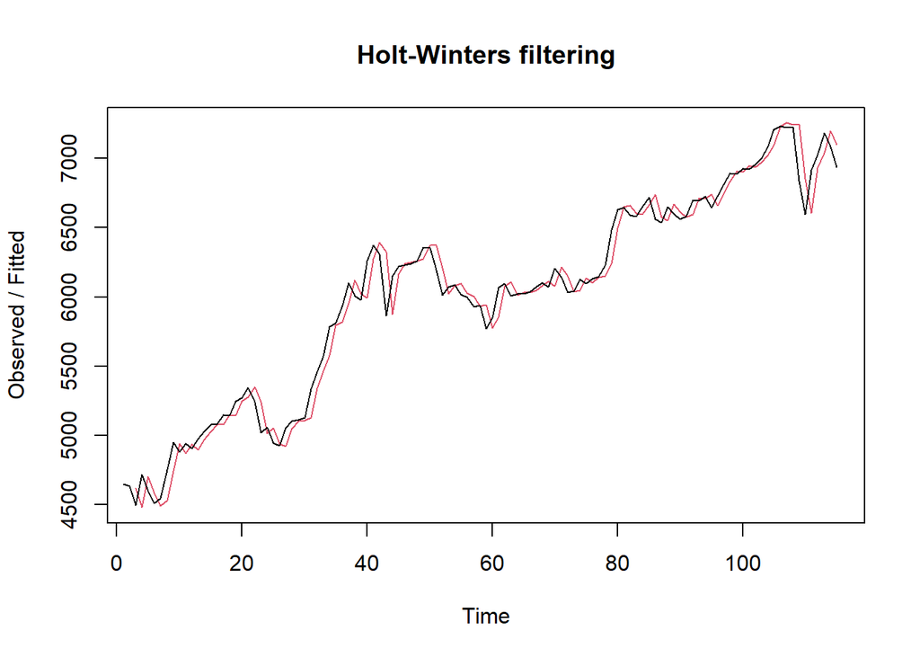

```r
plot(des.opt)
```

```r
#ramalan
ramalandesopt<- forecast(des.opt, h=28)
ramalandesopt
```

```
##     Point Forecast    Lo 80    Hi 80    Lo 95    Hi 95
## 116       6949.466 6792.310 7106.623 6709.117 7189.816
## 117       6961.966 6737.507 7186.425 6618.686 7305.246
## 118       6974.466 6696.850 7252.081 6549.890 7399.042
## 119       6986.965 6663.263 7310.667 6491.906 7482.025
## 120       6999.465 6634.035 7364.895 6440.588 7558.342
## 121       7011.964 6607.789 7416.140 6393.831 7630.098
## 122       7024.464 6583.716 7465.212 6350.399 7698.530
## 123       7036.964 6561.295 7512.632 6309.491 7764.436
## 124       7049.463 6540.166 7558.760 6270.561 7828.366
## 125       7061.963 6520.072 7603.854 6233.212 7890.713
## 126       7074.462 6500.819 7648.106 6197.150 7951.775
## 127       7086.962 6482.258 7691.666 6162.147 8011.777
## 128       7099.462 6464.273 7734.650 6128.024 8070.899
## 129       7111.961 6446.770 7777.152 6094.639 8129.283
## 130       7124.461 6429.673 7819.249 6061.875 8187.047
## 131       7136.961 6412.919 7861.002 6029.634 8244.287
## 132       7149.460 6396.454 7902.466 5997.837 8301.083
## 133       7161.960 6380.236 7943.684 5966.416 8357.504
## 134       7174.459 6364.224 7984.695 5935.311 8413.607
## 135       7186.959 6348.387 8025.531 5904.474 8469.444
## 136       7199.459 6332.697 8066.220 5873.861 8525.056
## 137       7211.958 6317.129 8106.788 5843.434 8580.482
## 138       7224.458 6301.660 8147.255 5813.161 8635.755
## 139       7236.957 6286.274 8187.641 5783.012 8690.903
## 140       7249.457 6270.951 8227.963 5752.962 8745.952
## 141       7261.957 6255.679 8268.235 5722.987 8800.926
## 142       7274.456 6240.442 8308.470 5693.068 8855.844
## 143       7286.956 6225.230 8348.682 5663.186 8910.725
```

Selanjutnya akan dilakukan perhitungan akurasi pada data latih maupun data uji dengan ukuran akurasi SSE, MSE dan MAPE.

# Akurasi Data Latih

```r
#Akurasi Data Training
ssedes.train1<-des.1$SSE
msedes.train1<-ssedes.train1/length(train_ma.ts)
sisaandes1<-ramalandes1$residuals
head(sisaandes1)
```

```
## Time Series:
## Start = 1
## End = 6
## Frequency = 1
## [1]         NA         NA -124.49853  139.97828    6.64908  -71.13083
```

```r
mapedes.train1 <- sum(abs(sisaandes1[3:length(train_ma.ts)]/train_ma.ts[3:length(train_ma.ts)])
                      *100)/length(train_ma.ts)

akurasides.1 <- matrix(c(ssedes.train1,msedes.train1,mapedes.train1))
row.names(akurasides.1)<- c("SSE", "MSE", "MAPE")
colnames(akurasides.1) <- c("Akurasi lamda=0.2 dan gamma=0.2")
akurasides.1
```

```
##      Akurasi lamda=0.2 dan gamma=0.2
## SSE                     4.593269e+06
## MSE                     3.994147e+04
## MAPE                    2.590253e+00
```

```r
ssedes.train2<-des.2$SSE
msedes.train2<-ssedes.train2/length(train_ma.ts)
sisaandes2<-ramalandes2$residuals
head(sisaandes2)
```

```
## Time Series:
## Start = 1
## End = 6
## Frequency = 1
## [1]         NA         NA -124.49853  207.20749  -36.71897  -98.53073
```

```r
mapedes.train2 <- sum(abs(sisaandes2[3:length(train_ma.ts)]/train_ma.ts[3:length(train_ma.ts)])
                      *100)/length(train_ma.ts)

akurasides.2 <- matrix(c(ssedes.train2,msedes.train2,mapedes.train2))
row.names(akurasides.2)<- c("SSE", "MSE", "MAPE")
colnames(akurasides.2) <- c("Akurasi lamda=0.6 dan gamma=0.3")
akurasides.2
```

```
##      Akurasi lamda=0.6 dan gamma=0.3
## SSE                     2.184852e+06
## MSE                     1.899872e+04
## MAPE                    1.583727e+00
```

Hasil akurasi dari data latih didapatkan skenario 2 dengan lamda=0.6 dan gamma=0.3 memiliki hasil yang lebih baik. Namun untuk kedua skenario dapat dikategorikan peramalan sangat baik berdasarkan nilai MAPE-nya.

# Akurasi Data Uji

```r
#Akurasi Data Testing
selisihdes1<-ramalandes1$mean-testing_ma$Close
selisihdes1
```

```
## Time Series:
## Start = 116
## End = 143
## Frequency = 1
##  [1]    0.5486256  244.3516252  293.6546248  377.1631904  137.3001740
##  [6]   68.3331536  -70.0044717 -119.4324291 -167.3955435 -135.0153959
## [11] -181.7524353 -252.0348857 -183.0551281 -197.5739065  -64.5946379
## [16]  -55.3858763  152.0616543  -55.9854441  -99.0603745  -93.3530779
## [21] -141.8381653 -139.6191497 -115.3937871  -86.6889325  213.0261761
## [26]  111.1455817  117.8597134   77.9185730
```

```r
SSEtestingdes1<-sum(selisihdes1^2)
MSEtestingdes1<-SSEtestingdes1/length(testing_ma$Close)
MAPEtestingdes1<-sum(abs(selisihdes1/testing_ma$Close)*100)/length(testing_ma$Close)

selisihdes2<-ramalandes2$mean-testing_ma$Close
selisihdes2
```

```
## Time Series:
## Start = 116
## End = 143
## Frequency = 1
##  [1]  -28.356353  220.378355  274.613063  363.053337  128.122029   64.086717
##  [7]  -69.319200 -113.815449 -156.846855 -119.534999 -161.340330 -226.691072
## [13] -152.779606 -162.366676  -24.455699  -10.315229  202.064010   -1.051380
## [19]  -39.194603  -28.555598  -72.108977  -64.958253  -35.801182   -2.164619
## [25]  302.482198  205.533312  217.179152  182.169720
```

```r
SSEtestingdes2<-sum(selisihdes2^2)
MSEtestingdes2<-SSEtestingdes2/length(testing_ma$Close)
MAPEtestingdes2<-sum(abs(selisihdes2/testing_ma$Close)*100)/length(testing_ma$Close)

selisihdesopt<-ramalandesopt$mean-testing_ma$Close
selisihdesopt
```

```
## Time Series:
## Start = 116
## End = 143
## Frequency = 1
##  [1]  -93.47061  167.63789  234.24638  335.06044  112.50292   60.84140
##  [7]  -60.19073  -92.31320 -122.97082  -73.28517 -102.71672 -155.69367
## [13]  -69.40842  -66.62170   83.66306  110.17732  334.93034  144.18874
## [19]  118.41931  141.43210  110.25250  129.77702  171.30787  217.31822
## [25]  534.33883  449.76373  473.78335  451.14771
```

```r
SSEtestingdesopt<-sum(selisihdesopt^2)
MSEtestingdesopt<-SSEtestingdesopt/length(testing_ma$Close)
MAPEtestingdesopt<-sum(abs(selisihdesopt/testing_ma$Close)*100)/length(testing_ma$Close)

akurasitestingdes <-
  matrix(c(SSEtestingdes1,MSEtestingdes1,MAPEtestingdes1,SSEtestingdes2,MSEtestingdes2,
           MAPEtestingdes2,SSEtestingdesopt,MSEtestingdesopt,MAPEtestingdesopt),
         nrow=3,ncol=3)
row.names(akurasitestingdes)<- c("SSE", "MSE", "MAPE")
colnames(akurasitestingdes) <- c("des ske1","des ske2","des opt")
akurasitestingdes
```

```
##          des ske1     des ske2      des opt
## SSE  7.363921e+05 7.295707e+05 1.504534e+06
## MSE  2.629972e+04 2.605610e+04 5.373336e+04
## MAPE 2.028529e+00 1.873444e+00 2.701025e+00
```